# Glow QML Type

Generates a blurred and colorized image of the source and places it behind the original, giving impression that the source is glowing. More...

| Import Statement: | `import Qt5Compat.GraphicalEffects` |
| --- | --- |
| Since: | QtGraphicalEffects 1.0 |
| Inherits: | Item |

- [List of all members, including inherited members](https://doc.qt.io/qt-6.9/qml-qt5compat-graphicaleffects-glow-members.html)

## Properties

- **cached** : alias
- **color** : alias
- **radius** : alias
- **samples** : alias
- **source** : alias
- **spread** : alias
- **transparentBorder** : alias

## Detailed Description

Source

Effect applied

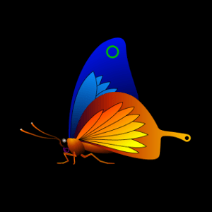

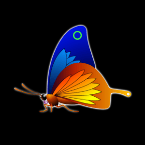

## Example

The following example shows how to apply the effect.

```
import QtQuick
import Qt5Compat.GraphicalEffects

Item {
    width: 300
    height: 300

    Rectangle {
        anchors.fill: parent
        color: "black"
    }

    Image {
        id: butterfly
        source: "images/butterfly.png"
        sourceSize: Qt.size(parent.width, parent.height)
        smooth: true
        visible: false
    }

    Glow {
        anchors.fill: butterfly
        radius: 8
        color: "white"
        source: butterfly
    }
}
```

## Property Documentation

### cached : alias

This property allows the effect output pixels to be cached in order to improve the rendering performance.

Every time the source or effect properties are changed, the pixels in the cache must be updated. Memory consumption is increased, because an extra buffer of memory is required for storing the effect output.

It is recommended to disable the cache when the source or the effect properties are animated.

By default, the property is set to `false`.

### color : alias

This property defines the RGBA color value which is used for the glow.

By default, the property is set to `"white"`.

Output examples with different color values

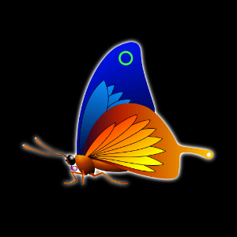

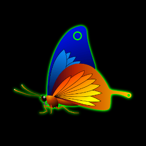

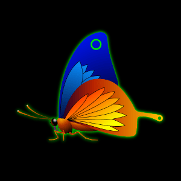

**color: #ffffff**

**color: #00ff00**

**color: #aa00ff00**

radius: 8

radius: 8

radius: 8

samples: 17

samples: 17

samples: 17

spread: 0.5

spread: 0.5

spread: 0.5

### radius : alias

Radius defines the softness of the glow. A larger radius causes the edges of the glow to appear more blurry.

Depending on the radius value, value of the samples should be set to sufficiently large to ensure the visual quality.

The ideal blur is achieved by selecting `samples` and `radius` such that `samples = 1 + radius * 2`, such as:

| Radius | Samples |
| --- | --- |
| 0 *(no blur)* | 1 |
| 1 | 3 |
| 2 | 5 |
| 3 | 7 |

By default, the property is set to `floor(samples/2)`.

Output examples with different radius values

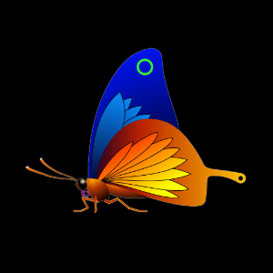

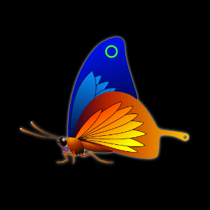

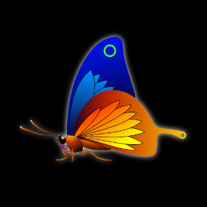

**radius: 0**

**radius: 6**

**radius: 12**

samples: 25

samples: 25

samples: 25

color: #ffffff

color: #ffffff

color: #ffffff

spread: 0

spread: 0

spread: 0

### samples : alias

This property defines how many samples are taken per pixel when edge softening blur calculation is done. Larger value produces better quality, but is slower to render.

Ideally, this value should be twice as large as the highest required radius value plus one, such as:

| Radius | Samples |
| --- | --- |
| 0 *(no blur)* | 1 |
| 1 | 3 |
| 2 | 5 |
| 3 | 7 |

By default, the property is set to `9`.

This property is not intended to be animated. Changing this property will cause the underlying OpenGL shaders to be recompiled.

### source : alias

This property defines the source item that is going to be used as source for the generated glow.

**Note:** It is not supported to let the effect include itself, for instance by setting source to the effect's parent.

### spread : alias

This property defines how large part of the glow color is strengthened near the source edges.

The values range from 0.0 to 1.0. By default, the property is set to `0.5`.

**Note:** The implementation is optimized for medium and low spread values. Depending on the source, spread values closer to 1.0 may yield visually asymmetrical results.

Output examples with different spread values

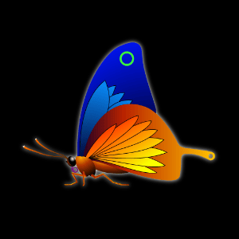

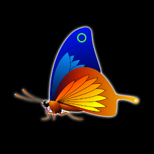

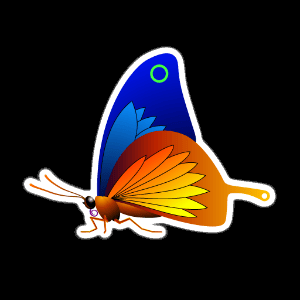

**spread: 0.0**

**spread: 0.5**

**spread: 1.0**

radius: 8

radius: 8

radius: 8

samples: 17

samples: 17

samples: 17

color: #ffffff

color: #ffffff

color: #ffffff

### transparentBorder : alias

This property determines whether or not the effect has a transparent border.

When set to `true`, the exterior of the item is padded with a transparent edge, making sampling outside the source texture use transparency instead of the edge pixels. Without this property, an image which has opaque edges will not get a blurred edge.

By default, the property is set to `true`. Set it to false if the source already has a transparent edge to make the blurring a tiny bit faster.

```
import QtQuick
import Qt5Compat.GraphicalEffects

Rectangle {
    width: 180
    height: 100

    Row {
        anchors.centerIn: parent
        spacing: 16

        Rectangle {
            id: normalRect
            width: 60
            height: 60
            color: "black"
            radius: 10
            layer.enabled: true
            layer.effect: Glow {
                samples: 15
                color: "blue"
                transparentBorder: false
            }
        }

        Rectangle {
            id: transparentBorderRect
            width: 60
            height: 60
            color: "black"
            radius: 10
            layer.enabled: true
            layer.effect: Glow {
                samples: 15
                color: "blue"
                transparentBorder: true
            }
        }
    }
}
```

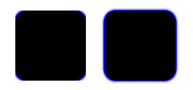

© The Qt Company Ltd  
Licensed under the GNU Free Documentation License, Version 1.3.  
https://doc.qt.io/qt-6.9/qml-qt5compat-graphicaleffects-glow.html